# Series AC Circuits

## Circuits

In a series circuit, in place of $R$, we use $Z$: - $Z_T = Z_1 + Z_2 + Z_3 \dots$

### Resistors

For a circuit with a resistor and ac source: - $i = I \sin \omega t = I \angle 0^\circ, \text{ where } I = I_m$ - $Z = R \angle 0^\circ$

### Inductors

For a circuit with an inductor and an AC source: - $i = I_m \sin (\omega t -90^\circ) = I\angle -90^\circ$, when $v = V \angle 0^\circ$ - $v = V\angle 90^\circ$, when $i = I \angle 0^\circ$ - $Z = X_L \angle 90^\circ$

### Capacitors

For a circuit with a capacitor and an AC source:

- $i = I_m \sin (\omega t + 90^\circ) = I\angle 90^\circ$, when $v = V \angle 0^\circ$
- $v = V\angle -90^\circ$, when $i = I \angle 0^\circ$

## RLC circuit

In an $RLC$ circuit, depending on the value of the resistance and reactances, the circuit is resistive, inductive or capacitive.

### Impedence Diagram

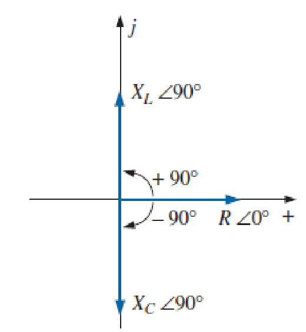

image

> **ⓘ Note**  
> $Z_C \neq X_C\angle90^\circ$  
> $Z_C = X_C\angle-90^\circ$

For any configuration, the angle associated with the total impedance is the angle by which the applied voltage leads the source current.

| Network | $\theta_{Z_T}$ |
| --- | --- |
| Inductive | $+ve$ |
| Capacitive | $-ve$ |

### Series ac Circuits (Configurations)

Impedances behave like resistors in series.
$$Z_T = \sum Z_n$$

Calculating in complex mode (recommended to use):

> **ⓘ Note**  
> In all places, angles are required in equations except in avg power formula ($P=VI\cos\theta$).  
> Each attribute has its own angle except avg power
- Polar notation
  $$\begin{align*}
  E &= I \cdot Z_T \\
  I &= \frac{E}{Z_T} \\
  V_{Z_x} &= I_T \cdot Z_x \\
  I_{Z_x} &= I \\
  \end{align*}$$
- Rectangular notation

$$\begin{align*}
Z &= R+j(X_L-X_C) \\
\end{align*}$$

Calculating in non-complex mode (not recommended to use):

$$\begin{align*}
Z &= \sqrt{R^2+X} \\
X &= X_L-X_C\\
\theta &= \tan^{-1} \frac{X}{R} \\
\end{align*}$$

Calculations that are complex independant:

$P=EI\cos\theta$

#### Voltage Divider Rule

$V_x = \dfrac{E}{Z_T}Z_x$

> **ⓘ Note**  
> Basically, this is Ohm’s law. The only change is that $I$ has been expanded

$V_x = I \cdot Z_x = \dfrac{E}{Z_T}Z_x$

#### Kirchoff’s Voltage Law

The sum of the input voltages and voltage drops in a closed loop is zero

### Resonance

Condition for resonance:

$$X_L = X_C$$

Frequency:

$$f = \frac{1}{2\pi\sqrt{LC}}$$

Derivation for $f$

> **ⓘ Note**  
> This is very simple, use when you forget the formula for $f$, all you need to remember is the condition for resonace.

$$\begin{align*}
X_L &= X_C \\
\omega L &= \frac{1}{\omega C} \\
2\pi fL &= \frac{1}{2\pi fC} \\
f^2 &= \frac{1}{(2\pi)^2LC} \\
f& = \frac{1}{2\pi\sqrt{LC}} \\
\end{align*}$$

### Applying the general approach to a series RLC circuit

- Apply the phasor notation

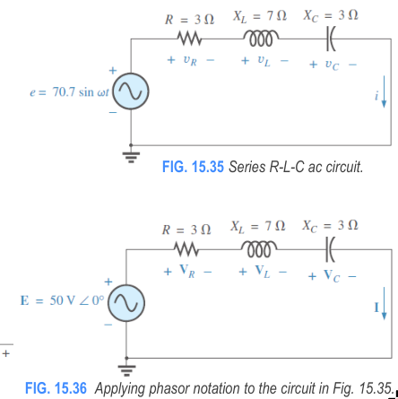

image

## Frequency Response for Series ac Circuits

In a series R-L-C circuit: - At very low frequencies, the total impedance will be determined primarily by the capacitor (C). - At very high frequencies, the total impedance will be determined primarily by the inductor (L).

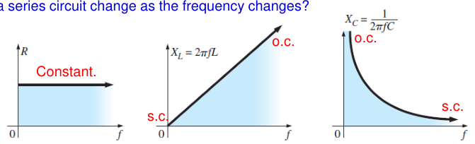

image